# bootNet: identifying robust classifiers in methylation data

08 April, 2016

## Overview

`bootNet` is a wrapper for the fantastic glmnet<sup>[1]</sup> `R` package

- it brings bootstrapping and parallel processing to an Elastic-net framework

Currently this script is set up to analyse methylation data in the form of beta matrices

- the beta matrix must have CpG sites as rows and samples as columns for `bootNet` to work

Future updates will allow analysis of various types of data, forming the basis of an **integrative omics** approach

## Reasoning

- analysis tools for methlyation data (especially 27k/450k/850k) are fairly limited
  - they are mostly inherited 'liftovers' from traditional expression analyses (i.e. `limma`)
- most methods are slow
  - dealing with half a million sites (nearly a million with new chip)
- beta values are special …
  - most don't fit normal distribution
  - bounded between \(0 - 1\)
- no easy way to integrate layers of data

**Can we create an analysis method that is robust to both the outcome variable as well as the predictor variables, that is also fast and could possibly be developed into an integrative omics approach?**

## Ridge-Regression

Ridge regression addresses some of the problems of Ordinary Least Squares (OLS) by imposing a penalty on the size of coefficients

- the Ridge coefficients minimise a penalised residual sum of squares
- Ridge regression keeps all the variables in and shrinks the coefficients towards zero.

Ridge is doing:

- shrinkage
- but **not** variable selection
- dense model

In glmnet Ridge regression is selected by setting \(\alpha = 0\) e.g. **\[fit.Ridge = glmnet(x, y , \alpha = 0)\]**

## LASSO (Least Absolute Shrinkage and Selection Operator)

A regression analysis method that performs both variable selection and regularisation in order to enhance the prediction accuracy and interpretability of the statistical model it produces

LASSO is doing:

- shrinkage
- **and** variable selection
- sparse model

In glmnet LASSO is selected by setting \(\alpha = 1\) *(this is also the default option)* eg. \[fit.LASSO = glmnet(x, y , \alpha = 1)\]

## Ridge vs LASSO

- **in science / statistics, there is no rule that means that you should always use one technique over another**
  - situation dependent model selection
- the LASSO encourages sparse models, whereas with Ridge you’ll get a dense model
  - if the *‘true model’* is quite dense, you expect to do better with Ridge
  - if the *‘true model’* is quite sparse, you expect to do better with the LASSO
- not knowing the *‘true model’*, it's typical to apply both methods and use cross-validation to determine the best model

… or … enter …

## Elastic-net

- we now know that:
  - the Ridge penalty shrinks the coefficients of correlated predictors towards each other
  - while the LASSO tends to pick one of them and discard the others
- the Elastic-net penalty mixes these two methods
  - if predictors are correlated in groups, an \(\alpha=0.5\) tends to select the groups in or out together
- Elastic-net is **useful** when there are **multiple features** which are **correlated** with one another
  - LASSO is likely to pick one of these at random, while Elastic-net is likely to pick both

A practical advantage of trading-off between LASSO and Ridge is it allows Elastic-Net to inherit some of Ridge’s stability under rotation.

## Elastic-net overcomes limitations

The Elastic-net helps overcome some of the limitations of Ridge and LASSO:

- When \(p > n\) (the number of covariates is greater than the sample size) LASSO can select only \(n\) covariates
- if there is **a group of highly correlated variables**, then the **LASSO** tends to **select one variable** from a group and ignore the others (example of CpGs in methylation analysis, use of **LASSO results in no DMRs**)
- even when \(n > p\), if the covariates are strongly correlated, Ridge regression tends to perform better
  - explaining why Elastic-net favoring \(\alpha\) towards 0 (Ridge) results in the detection of DMRs when looking at 450K data
  - this is referred to as the grouping effect and is generally considered desirable since, in many applications, such **identifying genes associated with a disease, one would like to find all the associated covariates**, rather than selecting only one from each set of strongly correlated covariates, as LASSO often does
- selecting only a single covariate from each group will typically result in increased prediction error, since the model is less robust (which is why Ridge regression often outperforms LASSO)

## glmnet

> *Extremely efficient procedures for fitting the entire LASSO or Elastic-net regularization path for linear regression, logistic and multinomial regression models, Poisson regression and the Cox model.* <sup>[1]</sup>
- `glmnet` is an `R` package which can be used to fit Regression models, LASSO model and others
- \(\alpha\) argument determines what type of model is fit.
  - when **\(\alpha=0\), a Ridge model** is fit
  - and if **\(\alpha=1\), a LASSO model** is fit.
- super efficient/fast FORTRAN code (can analyse large data sets quickly)

These methods are very powerful. In particular, they can be applied to very large data where the **number of variables might be in the thousands or even millions** (in our case genomic data).

## bootNet: what is it?

`bootNet` is a wrapper I wrote for `glmnet` to help **identify methylation sites** (CpGs) which predict an outcome

- the outcome can either be:
  - **quantitative** (continuous, i.e. age, BMI, weight … )
  - **qualitative** (categorical, i.e. gender, smoking, case/control … )

I integrated the ability to perform bootstrapping for a given number of iterations

Additionally, I wrote a second function to allow **parallisation**

- this allows a user to select the number of processors (cores) to split the task across
- running on multiple cores greatly speeds up analysis (as we'll see later)

## The functions

### **bootNet()**

- bootstrap implementation of `glmnet` Elastic-net framework

```r
bootNet(data = x, outcome = y, Alpha = 0.1, iter = 1000, sub_sample = 0.666,
    sampleID = sampleID)
```

### **bootNet.parallel()**

- a parallel version of the `bootNet` function to utalise multiple cores if available

```r
bootNet.parallel(data = x, outcome = y, Alpha = 0.1, iter = 1000, sub_sample = 0.666,
    cores = 4, sampleID = sampleID)
```

## Example usage:

What do you need to provide the `bootNet` script?

- *data* - methylation beta matrix* (formatted CpG sites as rows, samples as columns)
- *outcome* - either as numeric (quantitative trait) or as factor (qualitative trait)
- *Alpha* - sets the mixture between Ridge-regression and LASSO
- *iter* - the number of iterations to bootstrap
- *sub_sample* - percentage of sample/case-control groups to sub-sample for bootstrapping
- *sampleID* - a list of sample IDs (usually the column names of the beta matrix). These MUST be in the same order as the samples in the beta matrix
- *cores* - number of cores to use for bootNet.parallel

* future versions of `bootNet` will be able to analyse many different types of data (i.e. SNP, expression, phenotypic, …)

## In action

Example data set: whole blood vs bucal cells

- **656** whole blood methylomes
- **75** bucal methylomes
- **2500** iterations
  - **66.66%** subsampling
- provided \(\alpha = 0.1\)
- **identified 27 CpG** sites 100% of the time
  - each of these sites came through every iteration
  - perfect discriminators

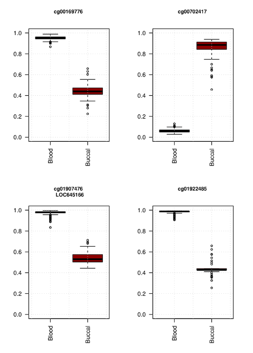

## Performance

A few test examples showing systems and performance metrics

**Experiment 1:** 24 samples run on Illumina 450K methylation array (**24 columns, 446280 rows**). Phenotype was quantitative (age)

- System used (Dell laptop: Precision M4800):
  - Intel Core i7-4900MQ (4 core, 8 threads)
  - 32GB DDR3
  - 256GB SSD
  - Linux - 4.3.0-towo.3-siduction-amd64 x86_64 (64 bit)
- Running **100 iterations** and using **4 cores** the maximum observed RAM usage was **20GB**, taking **85.6 seconds** or (1.4 minutes)

## Performance

A few test examples showing systems and performance metrics

**Experiment 2:** 75 samples run on Illumina 450K methylation array (**75 columns, 445998 rows**). Phenotype was quantitative (glucose)

## To do list

- add example data set and a decent tutorial
- include additional quality checks
  - ensure outcome is either numeric or factor
  - check for missing data (NAs) in both data and outcome
- explore bias estimation and performance of selected markers
- implement a double-bootstrap method as an additional way to explore performance metrics
  - separate training and test data
  - bootstrap both data sets
  - compare selected sites
- look into AUC and ROC as another form of marker selection/validation
- add an argument to perform "leave one out" analysis (replaces sub-sampling)
- write up as manuscript
  - **bootNet: identifying robust classifiers in methylation data**

## References

<sup>1</sup> Jerome Friedman, Trevor Hastie, Robert Tibshirani (2010). Regularization Paths for Generalized Linear Models via Coordinate Descent. Journal of Statistical Software, 33(1), 1-22. URL http://www.jstatsoft.org/v33/i01/

### Getting a copy

`bootNet` is currently housed in a private Github repository (https://github.com/sirselim/bootNet) and will be made publicly available upon publication. If you would like to try it out please feel free to contact me directly: m.benton@qut.edu.au